# Loading Data

```python
pip install pykan
```

```python
pip install pandas
```

```python
import pandas as pd
```

```python
data = pd.read_csv('C:\\Users\\chris\\OneDrive\\Desktop\\Github\\KAN\\DataCoSupplyChainDataset.csv', header=0, encoding='unicode_escape')
```

```python
data
```

|  | Type | Days for shipping (real) | Days for shipment (scheduled) | Benefit per order | Sales per customer | Delivery Status | Late_delivery_risk | Category Id | Category Name | Customer City | ... | Order Zipcode | Product Card Id | Product Category Id | Product Description | Product Image | Product Name | Product Price | Product Status | shipping date (DateOrders) | Shipping Mode |
| --- | --- | --- | --- | --- | --- | --- | --- | --- | --- | --- | --- | --- | --- | --- | --- | --- | --- | --- | --- | --- | --- |
| 0 | DEBIT | 3 | 4 | 91.250000 | 314.640015 | Advance shipping | 0 | 73 | Sporting Goods | Caguas | ... | NaN | 1360 | 73 | NaN | http://images.acmesports.sports/Smart+watch | Smart watch | 327.750000 | 0 | 2/3/2018 22:56 | Standard Class |
| 1 | TRANSFER | 5 | 4 | -249.089996 | 311.359985 | Late delivery | 1 | 73 | Sporting Goods | Caguas | ... | NaN | 1360 | 73 | NaN | http://images.acmesports.sports/Smart+watch | Smart watch | 327.750000 | 0 | 1/18/2018 12:27 | Standard Class |
| 2 | CASH | 4 | 4 | -247.779999 | 309.720001 | Shipping on time | 0 | 73 | Sporting Goods | San Jose | ... | NaN | 1360 | 73 | NaN | http://images.acmesports.sports/Smart+watch | Smart watch | 327.750000 | 0 | 1/17/2018 12:06 | Standard Class |
| 3 | DEBIT | 3 | 4 | 22.860001 | 304.809998 | Advance shipping | 0 | 73 | Sporting Goods | Los Angeles | ... | NaN | 1360 | 73 | NaN | http://images.acmesports.sports/Smart+watch | Smart watch | 327.750000 | 0 | 1/16/2018 11:45 | Standard Class |
| 4 | PAYMENT | 2 | 4 | 134.210007 | 298.250000 | Advance shipping | 0 | 73 | Sporting Goods | Caguas | ... | NaN | 1360 | 73 | NaN | http://images.acmesports.sports/Smart+watch | Smart watch | 327.750000 | 0 | 1/15/2018 11:24 | Standard Class |
| ... | ... | ... | ... | ... | ... | ... | ... | ... | ... | ... | ... | ... | ... | ... | ... | ... | ... | ... | ... | ... | ... |
| 180514 | CASH | 4 | 4 | 40.000000 | 399.980011 | Shipping on time | 0 | 45 | Fishing | Brooklyn | ... | NaN | 1004 | 45 | NaN | http://images.acmesports.sports/Field+%26+Stre... | Field & Stream Sportsman 16 Gun Fire Safe | 399.980011 | 0 | 1/20/2016 3:40 | Standard Class |
| 180515 | DEBIT | 3 | 2 | -613.770019 | 395.980011 | Late delivery | 1 | 45 | Fishing | Bakersfield | ... | NaN | 1004 | 45 | NaN | http://images.acmesports.sports/Field+%26+Stre... | Field & Stream Sportsman 16 Gun Fire Safe | 399.980011 | 0 | 1/19/2016 1:34 | Second Class |
| 180516 | TRANSFER | 5 | 4 | 141.110001 | 391.980011 | Late delivery | 1 | 45 | Fishing | Bristol | ... | NaN | 1004 | 45 | NaN | http://images.acmesports.sports/Field+%26+Stre... | Field & Stream Sportsman 16 Gun Fire Safe | 399.980011 | 0 | 1/20/2016 21:00 | Standard Class |
| 180517 | PAYMENT | 3 | 4 | 186.229996 | 387.980011 | Advance shipping | 0 | 45 | Fishing | Caguas | ... | NaN | 1004 | 45 | NaN | http://images.acmesports.sports/Field+%26+Stre... | Field & Stream Sportsman 16 Gun Fire Safe | 399.980011 | 0 | 1/18/2016 20:18 | Standard Class |
| 180518 | PAYMENT | 4 | 4 | 168.949997 | 383.980011 | Shipping on time | 0 | 45 | Fishing | Caguas | ... | NaN | 1004 | 45 | NaN | http://images.acmesports.sports/Field+%26+Stre... | Field & Stream Sportsman 16 Gun Fire Safe | 399.980011 | 0 | 1/19/2016 18:54 | Standard Class |

180519 rows × 53 columns

```python
from sklearn.preprocessing import StandardScaler
from sklearn.decomposition import PCA
from sklearn.impute import SimpleImputer

# Identifying numerical columns
numerical_cols = data.select_dtypes(include=['float64', 'int64']).columns

# Checking for missing values in numerical columns
missing_data = data[numerical_cols].isna().sum()

# Impute missing values using the mean of each column
imputer = SimpleImputer(strategy='mean')
data_numerical_imputed = imputer.fit_transform(data[numerical_cols])

# Standardizing the numerical data
scaler = StandardScaler()
data_numerical_scaled = scaler.fit_transform(data_numerical_imputed)

# Display missing data information
missing_data
```

```
Days for shipping (real)              0
Days for shipment (scheduled)         0
Benefit per order                     0
Sales per customer                    0
Late_delivery_risk                    0
Category Id                           0
Customer Id                           0
Customer Zipcode                      3
Department Id                         0
Latitude                              0
Longitude                             0
Order Customer Id                     0
Order Id                              0
Order Item Cardprod Id                0
Order Item Discount                   0
Order Item Discount Rate              0
Order Item Id                         0
Order Item Product Price              0
Order Item Profit Ratio               0
Order Item Quantity                   0
Sales                                 0
Order Item Total                      0
Order Profit Per Order                0
Order Zipcode                    155679
Product Card Id                       0
Product Category Id                   0
Product Description              180519
Product Price                         0
Product Status                        0
dtype: int64
```

# Performing PCA on the Data to Load it into the KAN model

```python
# Dropping the 'Order Zipcode' column from the data used for PCA
numerical_cols = numerical_cols.drop(['Order Zipcode', 'Product Description'])  # Excluding non-applicable columns

# Reapplying imputation and scaling on the adjusted dataset
data_numerical_imputed = imputer.fit_transform(data[numerical_cols])
data_numerical_scaled = scaler.fit_transform(data_numerical_imputed)

# Performing PCA
pca = PCA()
pca.fit(data_numerical_scaled)

# Explained variance ratio
explained_variance_ratio = pca.explained_variance_ratio_
cumulative_explained_variance = explained_variance_ratio.cumsum()

# Display the explained variance
explained_variance_ratio, cumulative_explained_variance
```

```
(array([2.61802215e-01, 1.33861248e-01, 1.03836947e-01, 9.12563227e-02,
        8.20494184e-02, 6.13775231e-02, 5.84434957e-02, 5.83434636e-02,
        5.16457461e-02, 4.66264889e-02, 2.13137947e-02, 8.48738448e-03,
        5.64914789e-03, 5.34520709e-03, 4.86719773e-03, 2.81147469e-03,
        1.76228661e-03, 5.16228922e-04, 4.40947148e-06, 3.50598503e-12,
        2.50226757e-31, 2.07242996e-31, 1.23694337e-31, 4.26528111e-33,
        1.93820488e-33, 1.90677590e-33, 1.90677590e-33]),
 array([0.26180221, 0.39566346, 0.49950041, 0.59075673, 0.67280615,
        0.73418367, 0.79262717, 0.85097063, 0.90261638, 0.94924287,
        0.97055666, 0.97904405, 0.9846932 , 0.9900384 , 0.9949056 ,
        0.99771707, 0.99947936, 0.99999559, 1.        , 1.        ,
        1.        , 1.        , 1.        , 1.        , 1.        ,
        1.        , 1.        ]))
```

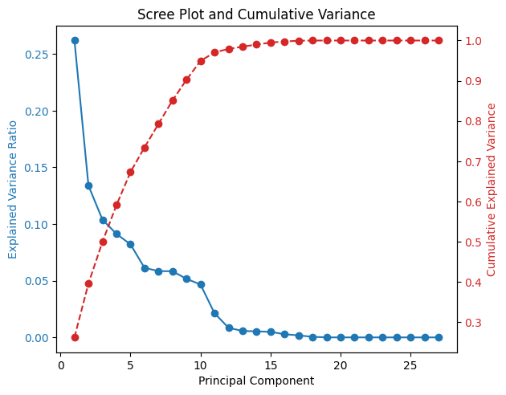

```
Index(['Order Item Product Price', 'Sales', 'Benefit per order',
       'Customer Zipcode', 'Order Id'],
      dtype='object')
```

```python
import matplotlib.pyplot as plt
import numpy as np

# Plotting the Scree plot and the Cumulative Variance plot
fig, ax1 = plt.subplots()

color = 'tab:blue'
ax1.set_xlabel('Principal Component')
ax1.set_ylabel('Explained Variance Ratio', color=color)
ax1.plot(range(1, len(explained_variance_ratio) + 1), explained_variance_ratio, marker='o', color=color)
ax1.tick_params(axis='y', labelcolor=color)

ax2 = ax1.twinx()  # instantiate a second axes that shares the same x-axis
color = 'tab:red'
ax2.set_ylabel('Cumulative Explained Variance', color=color)
ax2.plot(range(1, len(cumulative_explained_variance) + 1), cumulative_explained_variance, marker='o', linestyle='--', color=color)
ax2.tick_params(axis='y', labelcolor=color)

fig.tight_layout()  # otherwise the right y-label is slightly clipped
plt.title('Scree Plot and Cumulative Variance')
plt.show()

# Identifying the most important features for the first few principal components
n_components_to_inspect = 5  # Number of principal components to examine
most_important_features_idx = [np.abs(pca.components_[i]).argmax() for i in range(n_components_to_inspect)]
most_important_features = numerical_cols[most_important_features_idx]

most_important_features
```

# KAN

```python
import torch
from sklearn.model_selection import train_test_split
from sklearn.preprocessing import StandardScaler
```

```python
df = data.copy()
```

```python
# Define the features and target for the model
features = ['Order Item Cardprod Id', 'Sales', 'Customer Zipcode', 'Order Item Id']
target = 'Benefit per order'

# Check and drop rows with missing values for simplicity
if df[features + [target]].isna().sum().any():
    df = df.dropna(subset=features + [target])

# Prepare inputs and outputs
X = df[features].values
y = df[target].values

# Scale features
scaler = StandardScaler()
X_scaled = scaler.fit_transform(X)
```

```python
# Convert to tensors
X_tensor = torch.from_numpy(X_scaled.astype(np.float32))
y_tensor = torch.from_numpy(y.astype(np.float32)).unsqueeze(1)  # Ensuring y is in the shape [n_samples, 1]

# Split the data into training and test sets
X_train, X_test, y_train, y_test = train_test_split(X_tensor, y_tensor, test_size=0.2, random_state=42)
```

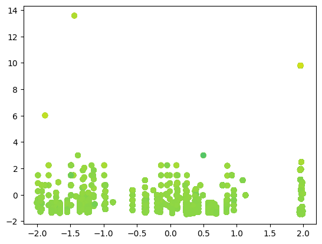

```python
dataset = {}

dataset['train_input'] = X_train
dataset['test_input'] = X_test
dataset['train_label'] = y_train
dataset['test_label'] = y_test

X = dataset['train_input']
y = dataset['train_label']
plt.scatter(X[:,0], X[:,1], c=y[:,0])
```

## Regression Model

KAN Model Architecture

Grid: The grid parameter controls the resolution of the tessellation grid used by KAN. Each input dimension is divided into a number of intervals equal to the grid size.

- grid=5: This means that each feature is divided into 5 intervals. The KAN will use these intervals to partition the input space and fit local models (polynomials) within each partition. This helps in modeling non-linear relationships without needing a massive number of training data points.

k: The k parameter denotes the degree of the polynomial used in each partition.

- k=3: This suggests that within each of the partitions created by the grid, a third-degree polynomial is used to model the relationship between the inputs and the output. Higher degrees allow the model to capture more complex patterns but can also lead to overfitting if not controlled properly.

```python
# Then continue with your existing code
from kan import *
import torch.nn.functional as F

# Initialize the KAN model
model = KAN(width=[4,6,2], grid=5, k=3)  # Adjust based on number of features and desired output
```

```python
image_folder = 'video_img'
```

```python
def train_acc():
    return torch.mean((torch.round(model(dataset['train_input'])[:,0]) == dataset['train_label'][:,0]).float())

def test_acc():
    return torch.mean((torch.round(model(dataset['test_input'])[:,0]) == dataset['test_label'][:,0]).float())


results = model.train(dataset, opt="LBFGS", steps=100, metrics=(train_acc, test_acc),save_fig=True, beta=10,img_folder=image_folder);

results['train_acc'][-1], results['test_acc'][-1]
```

```
train loss: 1.02e+02 | test loss: 1.04e+02 | reg: 2.38e+02 : 100%|█| 100/100 [1:11:48<00:00, 43.09s/
```

```
(0.0007063124794512987, 0.0008586306357756257)
```

```python
print(f"Training Accuracy: {results['train_acc'][-1]}")
print(f"Testing Accuracy: {results['test_acc'][-1]}")
```

```
Training Accuracy: 0.0007063124794512987
Testing Accuracy: 0.0008586306357756257
```

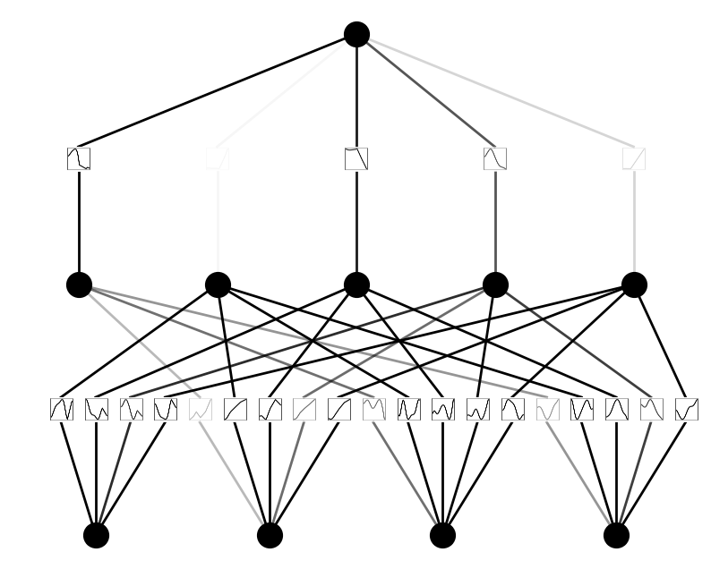

```python
model = model.prune()
model(dataset['train_input'])
model.plot(scale=1)
```

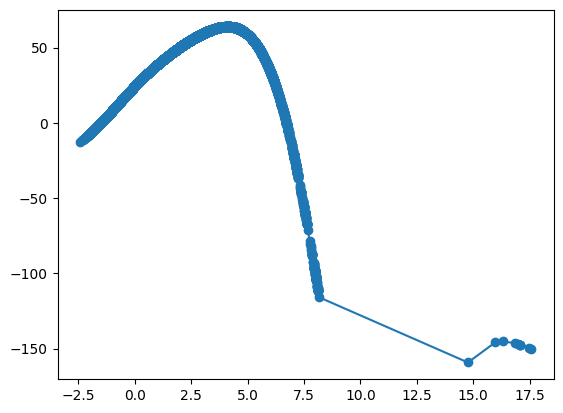

```python
l = 1
i = 0
j = 0

inputs = model.spline_preacts[l][:,j,i]
outputs = model.spline_postacts[l][:,j,i]
# they are not ordered yet
rank = np.argsort(inputs)
inputs = inputs[rank]
outputs = outputs[rank]
plt.plot(inputs, outputs, marker="o")
```

```python
pip install moviepy
```

```python
import os
import numpy as np
import moviepy.video.io.ImageSequenceClip # moviepy == 1.0.3

video_name='video'
fps=5

fps = fps
files = os.listdir(image_folder)
train_index = []
for file in files:
    if file[0].isdigit() and file.endswith('.jpg'):
        train_index.append(int(file[:-4]))

train_index = np.sort(train_index)

image_files = [image_folder+'/'+str(train_index[index])+'.jpg' for index in train_index]
```

```python
clip = moviepy.video.io.ImageSequenceClip.ImageSequenceClip(image_files, fps=fps)
clip.write_videofile(video_name+'.mp4')
```

[output not shown]

```python
lib = ['x','x^2','x^3','x^4','exp','log','sqrt','tanh','sin','tan','abs']
model.auto_symbolic(lib=lib)
formula = model.symbolic_formula()[0][0]
formula
```

[output not shown]

```python
# how accurate is this formula?
def acc(formula, X, y):
    batch = X.shape[0]
    correct = 0
    for i in range(batch):
        correct += np.round(np.array(formula.subs('x_1', X[i,0]).subs('x_2', X[i,1])).astype(np.float64)) == y[i,0]
    return correct/batch

print('train acc of the formula:', acc(formula, dataset['train_input'], dataset['train_label']))
print('test acc of the formula:', acc(formula, dataset['test_input'], dataset['test_label']))
```

[output not shown]

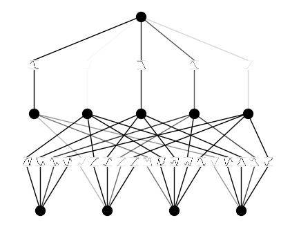

```python
model.plot()
```

## Classifier

```python
# Then continue with your existing code
from kan import *
import torch.nn.functional as F

# Initialize the KAN model
model = KAN(width=[4,2], grid=3, k=3)  # Adjust based on number of features and desired output
```

```python
def train_acc():
    return torch.mean((torch.argmax(model(dataset['train_input']), dim=1) == dataset['train_label']).float())

def test_acc():
    return torch.mean((torch.argmax(model(dataset['test_input']), dim=1) == dataset['test_label']).float())

results = model.train(dataset, opt="LBFGS", steps=20, metrics=(train_acc, test_acc),save_fig=True, beta=10,img_folder=image_folder);
```

```
train loss: 1.04e+02 | test loss: 1.03e+02 | reg: 1.05e+01 :   0%|           | 0/20 [00:28<?, ?it/s]
```

[output not shown]

```python
print(f"Training Accuracy: {results['train_acc'][-1]}")
print(f"Testing Accuracy: {results['test_acc'][-1]}")
```

[output not shown]

```python
model = model.prune()
model(dataset['train_input'])
model.plot(mask=True,scale=1.5)
```

[output not shown]

```python
l = 1
i = 2
j = 0

inputs = model.spline_preacts[l][:,j,i]
outputs = model.spline_postacts[l][:,j,i]
# they are not ordered yet
rank = np.argsort(inputs)
inputs = inputs[rank]
outputs = outputs[rank]
plt.plot(inputs, outputs, marker="o")
```

```python
import os
import numpy as np
import moviepy.video.io.ImageSequenceClip # moviepy == 1.0.3

video_name='video'
fps=5

fps = fps
files = os.listdir(image_folder)
train_index = []
for file in files:
    if file[0].isdigit() and file.endswith('.jpg'):
        train_index.append(int(file[:-4]))

train_index = np.sort(train_index)

image_files = [image_folder+'/'+str(train_index[index])+'.jpg' for index in train_index]

clip = moviepy.video.io.ImageSequenceClip.ImageSequenceClip(image_files, fps=fps)
clip.write_videofile(video_name+'.mp4')
```

```python
lib = ['x','x^2','x^3','x^4','exp','log','sqrt','tanh','sin','tan','abs']
model.auto_symbolic(lib=lib)
formula = model.symbolic_formula()[0][0]
formula
```

```python
# how accurate is this formula?
def acc(formula, X, y):
    batch = X.shape[0]
    correct = 0
    for i in range(batch):
        correct += np.round(np.array(formula.subs('x_1', X[i,0]).subs('x_2', X[i,1])).astype(np.float64)) == y[i,0]
    return correct/batch

print('train acc of the formula:', acc(formula, dataset['train_input'], dataset['train_label']))
print('test acc of the formula:', acc(formula, dataset['test_input'], dataset['test_label']))
```

[output not shown]